# Project2

2024-11-14

# Project 2

## Question 1

**Introduce the context of your dataset and describe its source(s). Include hyperlink(s) for where you retrieved it from as well as a picture (with citation directly below the image) related to your topic. Why did you pick this dataset to analyze, and what will you be investigating?**

This dataset is the stats of the top 500 players in the NBA. This is where I got my [data](https://www.basketball-reference.com/leagues/NBA_2024_per_game.html).

[figure not shown]

picture found here.

I picked this dataset because this is something that is interesting to me and I feel that I will get more involved using this dataset. I will be investigating the player’s stats like points, rebounds, assists, etc.

## Question 2

**Data Preparation: Describe how you obtained the data and imported it into R (either what specifically you downloaded or how you scraped it). Then detail the steps you took to process your data (e.g., what you did do with NA values, dates, factors, strings, renaming variables, etc.?). Include a brief description of the challenges you faced when preparing the data.**

I obtained the data by going on a website called basketball reference and downloaded the data from there. There wasn’t too much processing to do, since it was already sorted. I just had to remove some of the player’s which had multiple rows since they got traded in the middle of the season so they had average stats from both teams. There wasn’t that many challenges it was just tedious to do it manually.

## Question 3

**Variable Descriptions: Create a subset of your “cleaned dataset” (final version after all merging, variable creation, renaming, formatting, etc.) that only includes the variables of interest. Make a nicely formatted table that includes the name of each variable, its type, and a brief description.**

```r
library(ggplot2)
library(dplyr)
library(rvest)
nba_stats <- read.csv("sportsref_download.csv")

nba_cleaned <- nba_stats |>
  select(2, 3, 5, 11, 14, 21, 24, 25, 28, 30)
```

## Question 4

**Univariate Analyses**: Choose at least 4 of your variables and create univariate (1 variable) graphs to display them. Provide a brief description of the distribution, including relevant descriptive statistics, to go along with each graph.

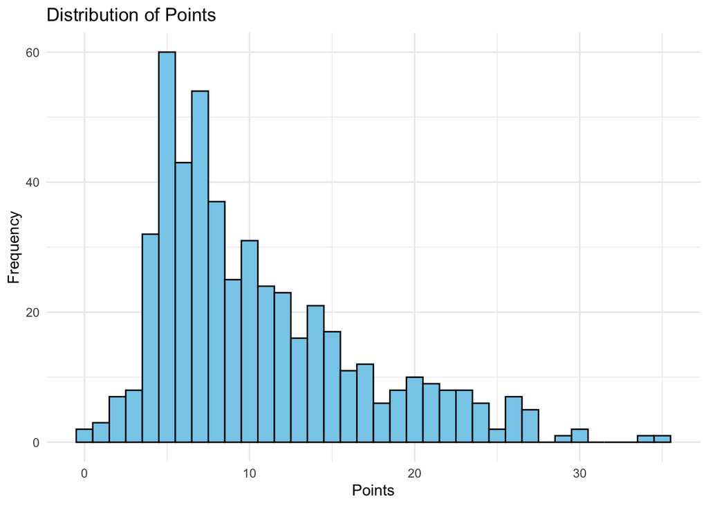

```r
# Plot for Points
ggplot(nba_cleaned, aes(x = PTS)) +
  geom_histogram(binwidth = 1, fill = "skyblue", color = "black") +
  labs(title = "Distribution of Points", x = "Points", y = "Frequency") +
  theme_minimal()
```

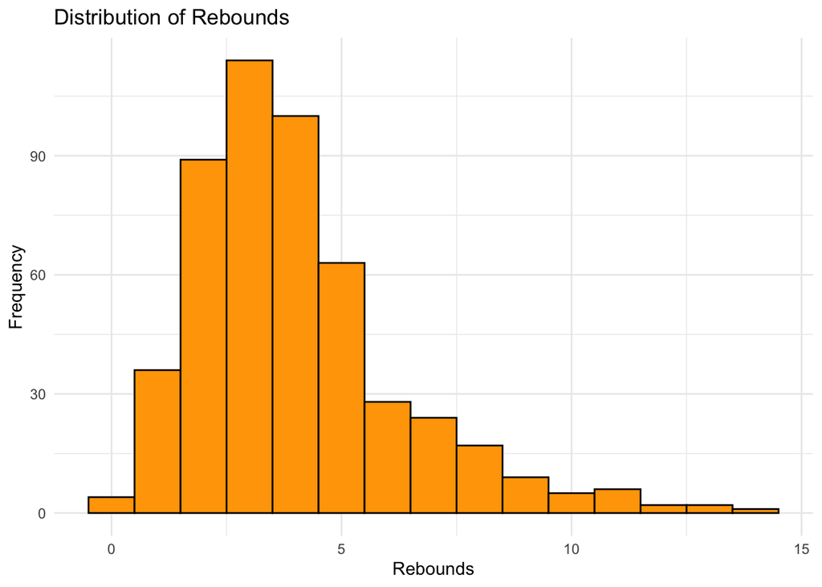

```r
# Plot for Rebounds
ggplot(nba_cleaned, aes(x = TRB)) +
  geom_histogram(binwidth = 1, fill = "orange", color = "black") +
  labs(title = "Distribution of Rebounds", x = "Rebounds", y = "Frequency") +
  theme_minimal()
```